# Every reporting rule of the two autoresearch loops on a harder bank: the donor-level regression with eSVD’s fitted library beats DESeq2, the fitted library matters when confounders vary within a donor, and the posterior’s floor on the library should go

Kevin Z. Lin (drafted by Claude)

2026-11-12

# 1 Overview

This document is built from the two autoresearch loops on the reported log fold change and its standard error (`autoresearch_lfcse/`, `autoresearch_lfcse2/`; their reports are `notes/RUN_nov11_claude.md` in each), from Kevin’s note of 2026-11-12 (`2026-11-12_autoresearch_additional-exploration-beyond-score.txt`), and from a new bank of simulated cohorts built for it, `lfcse-bank-3`. No new rule is proposed. Every rule the two loops considered is run again, as it was written, on a bank that is harder in the ways the note asks for, and is assessed on more than the score.

**The question.** Of the rules the two loops considered, which one should `eSVD2` report the log2 fold change and SE from, once the bank has strong confounders, genes of very different sparsity, few or many true DEGs, and replicate cohorts, and once each rule is also compared head to head with DESeq2, run with library sizes other than eSVD’s, and checked against its own significance calls?

What the document argues:

1. **`donor_wls` beats pseudobulk DESeq2 on all three banks**, by 0.252 nats per gene on the new bank, where it is the better of the two in 87% of cohorts (section 5).
2. **eSVD’s fitted library is worth having when a confounder varies within a donor, and only then.** With cell-level confounders, `donor_wls` with the summed counts as library scores 1.058 against 0.453 with the fitted library; with donor-level confounders, however strong, the two are equal (sections 6 and 7).
3. **The posterior’s floor of 0.1 on the fitted library hurts the rule.** For sparse genes the fitted library sits at the floor and carries no depth or covariate adjustment. Without the floor `donor_wls` gains 0.032 nats on the new bank and loses nothing elsewhere (section 7.3).
4. **Sparse genes are harder for every rule, and `donor_wls` attenuates the fold change of the sparsest ones**: its slope on the truth is 0.87 for genes with over 95% zeros (section 8).
5. **True DEGs replicate and null genes do not**, for every rule, and the replicate correlation of the null genes detects confounding a rule has left in (section 9).
6. **eSVD-DE’s own significance calls and the reported interval are two analyses.** On the new bank 76% of the genes the package calls have a `donor_wls@esvd_nofloor` interval that leaves out zero, and the package’s calls have a false discovery proportion of 19% at a nominal 5% (section 10).
7. **The recommendation**: report from `donor_wls` with the fitted library without its floor (`donor_wls@esvd_nofloor`); keep `state_adjusted` as the rule for the effect at fixed cell state, which is still a decision about the target and not about the rule (section 11).

*How to read.* Green boxes close each results section with what it changes; the blue box describes the new bank; grey boxes say which bank a section reads; the orange box in section 11 is the procedure. A reader of the boxes alone has the argument.

| Stage | What it does | Section |
| --- | --- | --- |
| Definitions | the rules, the library variants, the score, the six assessments | 2 |
| The new bank | what `lfcse-bank-3` holds and what was realized | 3 |
| Scores | every rule on the three banks, with the validity gates | 4 |
| DESeq2 | head to head, by stratum | 5 |
| Confounders | which rules survive strong donor-level and cell-level confounding | 6 |
| Library size | fitted library against summed counts and the standard estimates | 7 |
| Sparsity and DEG count | scores by gene sparsity and by the number of true DEGs | 8 |
| Replicates | agreement of the logFC between two cohorts of one population | 9 |
| Significance | significant genes against the $\pm 2$ SE interval | 10 |
| Recommendation | the rule to report from | 11 |

# 2 Definitions

## 2.1 Notation and the score

A cohort has cells $c$ in donors $d$, genes $g$, counts $A_{cg}$, an arm (case or control) per donor, and covariates. A **reporting rule** takes one fitted eSVD-DE cohort and returns, for every gene, a log2 fold change $\widehat\beta_g$ and a standard error $s_g$. The **score** of a cohort is the Gaussian negative log-likelihood of the true log2 fold change $\beta_g$ under the reported pair, averaged over genes, in nats per gene:
$$\frac{1}{p}\sum_g \left\{\tfrac12 \log(2\pi
s_g^2) +
\frac{(\widehat\beta_g - \beta_g)^2}{2 s_g^2}\right\}.$$
**Lower is better.** It rewards an accurate fold change and an SE that is neither too small nor too large.

Two truths are used. The **marginal** truth is the log2 ratio of mean expression between the populations of case and control donors at equal covariates and depth; it includes any difference in cell state between the arms. The **direct** truth is the case-control effect at fixed cell state. They differ only where the arms differ in cell state (`state = donor_arm` of banks 2 and 3). eSVD-DE’s convention is the marginal one.

Two **validity gates** from the loops are reported beside the score. `slope_weak` is the slope of the reported logFC on the truth over weak-effect genes (below 0.5 in absolute value); the loops required $[0.9, 1.1]$, so that a rule cannot win by shrinking. `se_strong` is the SE of strong-effect genes over the SE of other genes of the same expression level; the second loop required $[0.92, 1.08]$, so that a rule cannot win by an SE that follows the estimated logFC.

## 2.2 The rules

Every rule is the file the loops left, unedited (`autoresearch_lfcse2/candidates/`, `autoresearch_lfcse*/notes/RULE_*`).

| Name in the tables | Rule | Reads of the fit | From |
| --- | --- | --- | --- |
| `stored` | what 1.2.0 reports: log ratio of the arms’ mean posterior, SE from the posterior’s mixture variances | posterior | package |
| `null_rescaled` | `stored`, the logFC shifted by the empirical null’s mean and the SE multiplied by its SD | posterior, empirical null | baseline of loop 2 |
| `deshrunk` | `stored`’s logFC; between-donor SE of the posterior donor means divided by the shrinkage weight | posterior, library, nuisance rate | reference |
| `raw` | ratio of the arms’ means of donor means of $A/\ell$, delta-method SE between donors | library | reference |
| `raw_null` | `raw` with the empirical null’s shift and rescaling | library | baseline of loop 1 |
| `donor_wls` | weighted regression of $\log\{(y_{dg} + 1/2)/L_{dg}\}$ on the arm and the donor-level covariates, residual variance moderated across genes, logFC shifted by the null’s mean | library | kept by loop 1 |
| `gap_trend` | as `donor_wls` with voom-style weights and a variance trend in a covariate that contains the between-arm gap | library | withdrawn in loop 1 (fails `se_strong`) |
| `embed_prior` | `donor_wls` with the embedding’s predicted donor variance in the moderation prior | library, embedding | kept by loop 2, run A |
| `state_adjusted` | `donor_wls` on summaries with the embedding’s donor offset removed; the arm coefficients’ component along the loadings subtracted | library, embedding | kept by loop 2, run B |
| `deseq2` | DESeq2 on donor pseudobulk; design: every covariate (cell-level ones as donor means) and the arm | nothing | comparator |
| `deseq2_nocell` | the same without the cell-level covariates in the design | nothing | comparator |

Here $y_{dg}$ is the donor’s summed count and $L_{dg}$ its summed library. The intermediate commits the loops discarded are not rerun.

## 2.3 The library variants

`donor_wls`, `gap_trend`, `raw_null`, `embed_prior` and `state_adjusted` read a cells $\times$ genes library $\ell_{cg}$. The fit’s is $\ell_{cg} = \max\{\exp(z_g^\top C_c), 0.1\}$ over every covariate but the arm: the intercept, the log of the cell’s summed counts with a per-gene coefficient, and each other covariate with a per-gene coefficient. A variant is written `rule@library`.

| Library | What it is | Design of the rule |
| --- | --- | --- |
| (none) | the fitted library as the posterior uses it, floored at 0.1 | donor-level covariates |
| `esvd_nofloor` | the fitted library without the floor | donor-level covariates |
| `esvd_depth` | the fitted intercept and depth coefficient only, no floor | donor-level covariates |
| `total` | the cell’s summed counts | donor-level covariates |
| `total_cov` | the cell’s summed counts | donor-level covariates and the donor means of the cell-level ones |
| `sf_cov` | summed counts rescaled so that a donor’s total is DESeq2’s median-of-ratios size factor of the pseudobulk | as `total_cov` |
| `tmm_cov` | summed counts times edgeR’s TMM factor of the donor’s pseudobulk | as `total_cov` |
| `oracle` | the generator’s library times the true effect of the cell-level covariates (bank 3 only) | donor-level covariates |

`total_cov` is what an analyst without eSVD would do: pseudobulk by donor, normalize by depth, and put each covariate in the design at the donor level.

## 2.4 The six assessments

| Kevin’s request | What is computed | Section |
| --- | --- | --- |
| Head to head with DESeq2 | per cohort, the rule’s score minus DESeq2’s on the same genes; its mean, paired SE and the share of cohorts the rule wins | 5 |
| Raw or standard library against eSVD’s | each `rule@library` minus `rule`, paired within cohorts | 7 |
| Confounders with a larger effect than the arm | the factor `confound` of bank 3 | 3, 6 |
| Genes of high and low sparsity; few and many DEGs | genes binned by their share of zero counts; the factor `deg` | 3, 8 |
| Technical replicates | two cohorts per population; correlation of the logFC over true DEGs and over null genes | 9 |
| Significant genes against $\pm 2$ SE | of the genes a test calls at FDR 5%, the share with $\|\widehat\beta_g\| > 2 s_g$ | 10 |

# 3 The new bank

`lfcse-bank-3` holds 216 examples. An example is one **population** (the gene-level truth: 600 genes with their intercepts, loadings, over-dispersion, case-control and covariate effects) and **two replicate cohorts** drawn from it with new donors and new cells, each fitted end to end by eSVD2 1.2.0 at rank 5 (432 fits). Counts follow the eSVD model, with donor effects as in the second bank. Eight factors vary:

1. `donors`: 10, 20 or 40, half per arm.
2. `confound`: sex and age are in every cohort. `mild`: per-gene effects of SD 0.2, nearly balanced between arms (sex 40% against 60%). `donor`: effects of SD 0.5, sex 20% of controls against 80% of cases, cases older by one SD. `cell`: the mild donor-level covariates plus two cell-level ones, `Pct` (continuous, per-gene effect SD 0.3, cases higher by 0.8 within-donor SD) and `Phase` (binary, per-gene effect SD 0.5, 20% of control cells against 50% of case cells). A DEG’s effect has SD 0.6, so at `donor` and `cell` the confounders move every gene by about as much as the arm moves the DEGs.
3. `deg`: `few` (5% of genes with an effect, both signs, the others exactly null), `many` (30%, three in four positive, the others exactly null), `dense` (every gene nonzero, most weakly).
4. `state`: `none`; `donor` (donor-level cell states of rank 3 carry three quarters of the donor variance); `donor_arm` (the same, and the arms differ in mean state, so the marginal and direct truths differ).
5. `cells`: 50 per donor, or unequal (30 to 600).
6. `donor_sd`: 0.2 or 0.5 on the log scale.
7. `arm_sd`: equal donor variance in the arms, or three times larger in the cases.
8. `depth`: none, or a donor-level shift of a block of 15% of the genes.

Gene intercepts are uniform on $(-4, 1.5)$ in every cohort, so each cohort holds genes with a mean of 0.02 counts per cell beside genes with a mean of 4. The 216 examples are a balanced one-sixth fraction of the 1296 combinations: every level and every pair of levels of two factors appears equally often. There is one split, because nothing is tuned on this bank.

Table 1. Genes by their share of zero counts in the three banks (test splits of banks 1 and 2), with the share of genes whose nuisance rate is capped or at the boundary, and the share of a gene’s cells whose fitted library is below the posterior’s floor of 0.1.

| Bank | Share of zeros | Share of genes | Capped or boundary rate | Cells at the library floor |
| --- | --- | --- | --- | --- |
| bank 1 | under 50% | 99% | 8% | 0% |
| bank 1 | 50 to 80% | 1% | 1% | 0% |
| bank 1 | 80 to 95% | 0% |  |  |
| bank 1 | over 95% | 0% |  |  |
| bank 2 | under 50% | 54% | 33% | 0% |
| bank 2 | 50 to 80% | 18% | 45% | 1% |
| bank 2 | 80 to 95% | 21% | 50% | 44% |
| bank 2 | over 95% | 8% | 44% | 98% |
| bank 3 | under 50% | 33% | 43% | 0% |
| bank 3 | 50 to 80% | 23% | 52% | 3% |
| bank 3 | 80 to 95% | 27% | 56% | 49% |
| bank 3 | over 95% | 17% | 52% | 97% |

Every fit of the new bank succeeded (3 of 432 with a warning). On average 64% of a cohort’s counts are zero and 50% of its genes have a capped or boundary nuisance rate, against 73% on the Velmeshev cohort and 13% in the first bank. The first bank has almost no gene with more than half zeros; the new bank has 44% of its genes above 80%.

The last column of Table 1 is a finding of its own. The fitted library contains the gene’s intercept, so for a gene with under one count in ten cells it falls below 0.1 and the posterior sets it to 0.1 for every cell. For such a gene the “library” a rule reads is a constant: it has neither the depth nor the covariates in it. Section 7.3 measures what this costs.

The new bank covers what the note asks for: confounders as strong as the effect of interest at the donor level and at the cell level, genes from a few percent to 99% zeros within every cohort, 5% or 30% true DEGs among exact nulls, and a replicate cohort for every population. Building it exposed that the fitted library is constant for sparse genes because of the posterior’s floor.

# 4 Scores on the three banks

The test splits of `lfcse-bank-1` (288 cohorts) and `lfcse-bank-2` (288 cohorts), which no rule was tuned on, and all 432 cohorts of `lfcse-bank-3`. Every rule and DESeq2 were rerun on all of them by `02_apply-rules_claude.R`.

Table 2. Mean score (nats per gene, lower is better) of every rule on the three banks, under the marginal and the direct truth, ordered by the new bank’s marginal score. In bank 1 the two truths coincide.

| Method | Bank 1 | Bank 2, marginal | Bank 2, direct | Bank 3, marginal | Bank 3, direct |
| --- | --- | --- | --- | --- | --- |
| `donor_wls@esvd_nofloor` | -0.071 | 0.125 | 0.337 | 0.426 | 0.554 |
| `gap_trend` | -0.094 | 0.117 | 0.302 | 0.431 | 0.552 |
| `donor_wls` | -0.071 | 0.132 | 0.345 | 0.459 | 0.587 |
| `embed_prior` | -0.068 | 0.132 | 0.325 | 0.461 | 0.581 |
| `state_adjusted@esvd_nofloor` | -0.075 | 0.384 | -0.108 | 0.500 | 0.230 |
| `state_adjusted` | -0.075 | 0.390 | -0.102 | 0.532 | 0.264 |
| `raw_null` | 0.018 | 0.230 | 0.276 | 0.555 | 0.591 |
| `deseq2` | -0.017 | 0.194 | 0.414 | 0.711 | 0.806 |
| `null_rescaled` | 0.001 | 0.297 | 0.362 | 0.750 | 0.833 |
| `stored` | 0.226 | 0.463 | 0.512 | 0.807 | 0.856 |
| `deseq2_nocell` | -0.017 | 0.194 | 0.414 | 0.849 | 0.972 |
| `raw` | 0.118 | 0.324 | 0.543 | 0.875 | 1.034 |
| `deshrunk` | 0.101 | 0.567 | 0.660 | 0.905 | 0.938 |

Table 3. Diagnostics on the new bank under the marginal truth (the last slope under the direct truth). A calibrated rule has coverage 0.95 and an SD of z on exactly null genes of 1.

| Method | RMSE | Coverage of 95% | SD of z, null genes | Median logFC, null genes | slope_weak, marginal | slope_weak, direct | se_strong |
| --- | --- | --- | --- | --- | --- | --- | --- |
| `stored` | 0.535 | 0.953 | 0.852 | -0.092 | 0.871 | 0.938 | 1.049 |
| `null_rescaled` | 0.532 | 0.903 | 1.281 | -0.025 | 0.889 | 0.982 | 1.049 |
| `deshrunk` | 0.535 | 0.953 | 0.901 | -0.092 | 0.871 | 0.938 | 0.987 |
| `raw` | 0.554 | 0.820 | 1.457 | -0.095 | 0.898 | 0.948 | 1.027 |
| `raw_null` | 0.548 | 0.959 | 0.981 | -0.026 | 0.918 | 0.994 | 1.027 |
| `donor_wls` | 0.505 | 0.923 | 1.094 | -0.019 | 0.899 | 0.963 | 1.029 |
| `gap_trend` | 0.502 | 0.932 | 1.071 | -0.021 | 0.896 | 0.960 | 1.154 |
| `embed_prior` | 0.505 | 0.926 | 1.086 | -0.018 | 0.899 | 0.963 | 1.035 |
| `state_adjusted` | 0.472 | 0.903 | 0.998 | -0.018 | 0.512 | 0.932 | 1.028 |
| `donor_wls@esvd_nofloor` | 0.498 | 0.928 | 1.080 | -0.016 | 0.894 | 0.961 | 1.039 |
| `state_adjusted@esvd_nofloor` | 0.463 | 0.907 | 0.982 | -0.015 | 0.509 | 0.930 | 1.039 |
| `deseq2` | 0.820 | 0.940 | 0.996 | -0.033 | 0.932 | 0.981 | 1.012 |

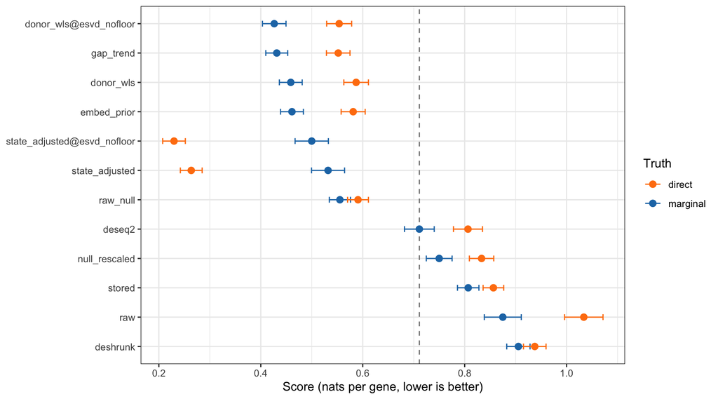

Figure 1. Mean score of each rule on the new bank under the two truths, with one standard error. The dashed line is DESeq2 under the marginal truth.

**The order of the rules carries over to the new bank.** Under the marginal truth the donor-level regressions (`donor_wls`, `embed_prior`, `gap_trend`) lead on all three banks, the posterior-based rules (`stored`, `null_rescaled`, `deshrunk`) trail DESeq2, and `raw_null` sits between. Under the direct truth `state_adjusted` leads by 0.324 nats on the new bank, as it did on the second.

**The gates.** `gap_trend` fails `se_strong` again (1.15 on the new bank, 1.20 on the second): its lead in Table 2 is the SE following the estimated logFC, and it stays withdrawn. `state_adjusted` has a `slope_weak` of 0.51 under the marginal truth, by construction (it removes the arms’ difference in cell state), and 0.93 under the direct truth. Every other rule’s marginal `slope_weak` is between 0.87 and 0.92 on the new bank, DESeq2’s is 0.93: the bank’s sparse genes pull every rule’s slope down, and section 8 shows where.

**Calibration.** `donor_wls` covers the truth 92.3% of the time at a nominal 95% on the new bank (94.0% on the second, 95.0% on the first), and the SD of its z-statistic on exactly null genes is 1.09: its SE is a few percent too small here. `stored` is too wide (SD of z 0.85) and biased on null genes (median logFC -0.09); `null_rescaled` is too narrow (coverage 90.3%).

**Failures.** `raw` and `raw_null` return a non-finite value for 120 genes in 61 cohorts of the new bank (a gene with no count in one arm); they are scored on the remaining genes. No other rule failed on any cohort.

Nothing in the new bank reverses the loops’ ranking. Under the marginal truth the donor-level regression family is best on all three banks; under the direct truth `state_adjusted` is. `gap_trend` fails the same gate it failed before. The posterior-based rules, including what 1.2.0 stores, are behind DESeq2 on every bank.

# 5 Head to head with DESeq2

All three banks. Per cohort, a rule’s score minus DESeq2’s over the same genes; negative means the rule is better. `deseq2` has every covariate in its design, cell-level ones as donor means.

Table 4. Each rule against DESeq2: mean over cohorts of the difference in score (paired SE), and the share of cohorts in which the rule scores better. Marginal truth unless stated.

| Method | bank 1: difference (SE) | bank 1: wins | bank 2: difference (SE) | bank 2: wins | bank 3: difference (SE) | bank 3: wins | Bank 3, direct: difference (SE) |
| --- | --- | --- | --- | --- | --- | --- | --- |
| `stored` | 0.243 (0.014) | 10% | 0.269 (0.015) | 12% | 0.096 (0.020) | 30% | 0.050 (0.020) |
| `null_rescaled` | 0.018 (0.003) | 43% | 0.103 (0.013) | 27% | 0.039 (0.022) | 34% | 0.027 (0.021) |
| `deshrunk` | 0.118 (0.013) | 3% | 0.373 (0.020) | 10% | 0.194 (0.020) | 28% | 0.131 (0.020) |
| `raw` | 0.135 (0.013) | 3% | 0.130 (0.017) | 24% | 0.164 (0.029) | 34% | 0.228 (0.029) |
| `raw_null` | 0.035 (0.004) | 26% | 0.036 (0.011) | 42% | -0.155 (0.019) | 52% | -0.215 (0.018) |
| `donor_wls` | -0.054 (0.002) | 99% | -0.062 (0.004) | 90% | -0.252 (0.017) | 87% | -0.219 (0.017) |
| `gap_trend` | -0.077 (0.002) | 100% | -0.077 (0.005) | 87% | -0.280 (0.017) | 90% | -0.255 (0.018) |
| `embed_prior` | -0.051 (0.002) | 99% | -0.062 (0.004) | 83% | -0.250 (0.017) | 84% | -0.225 (0.017) |
| `state_adjusted` | -0.058 (0.002) | 96% | 0.196 (0.097) | 78% | -0.179 (0.038) | 82% | -0.543 (0.022) |
| `donor_wls@esvd_nofloor` | -0.054 (0.002) | 99% | -0.069 (0.004) | 93% | -0.285 (0.017) | 94% | -0.253 (0.017) |
| `state_adjusted@esvd_nofloor` | -0.058 (0.002) | 96% | 0.190 (0.097) | 79% | -0.211 (0.038) | 83% | -0.577 (0.022) |
| `donor_wls@total_cov` | -0.050 (0.002) | 98% | -0.046 (0.003) | 82% | -0.054 (0.003) | 85% | -0.050 (0.003) |

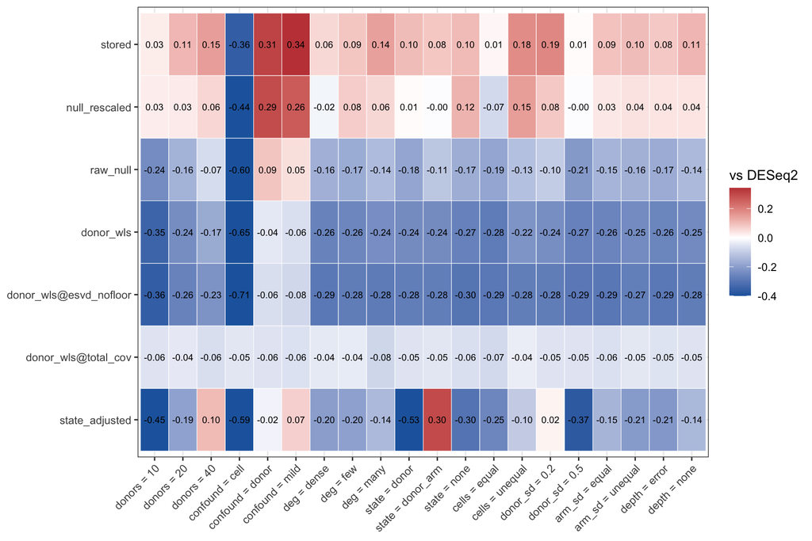

Figure 2. Score minus DESeq2’s on the new bank (marginal truth), by level of each factor. Blue: the rule is better than DESeq2; red: worse. The colour scale is capped at 0.4 nats.

**`donor_wls` beats DESeq2 on every bank and in every stratum of the new bank.** The margin is 0.054 nats on the first bank, 0.062 on the second and 0.252 on the new one, each many paired standard errors from zero, and `donor_wls` is the better of the two in 99%, 90% and 87% of cohorts.

**Where the margin comes from on the new bank.** At `confound = mild` and `donor` the margin is 0.060 and 0.045, the size seen on the earlier banks. At `confound = cell` it is 0.652. There DESeq2 has to adjust for the cell-level covariates through their donor means, which are nearly collinear with the arm, and its RMSE goes to 1.18 log2 units against 0.48 for `donor_wls`. Leaving the cell-level covariates out of DESeq2’s design (`deseq2_nocell`) trades variance for bias: its score at `confound = cell` is 1.518 with a coverage of 76%, and `donor_wls` beats it there by 1.065 (SE 0.077).

**The rules that do not beat DESeq2.** `stored`, `deshrunk`, `raw` and `null_rescaled` are behind DESeq2 on every bank; `raw_null` is behind on banks 1 and 2 and ahead on the new bank only because of `confound = cell`.

The rule the first loop kept is more accurate than DESeq2 by the loops’ score on all three banks and in every stratum of the new one, and the margin is ten times larger when confounders vary within a donor. What 1.2.0 stores today is less accurate than DESeq2 on all three.

# 6 Confounders

`lfcse-bank-3`, by level of `confound`.

Table 5. Score, RMSE of the logFC and coverage of the 95% interval on the new bank by level of `confound`, marginal truth.

| Method | Score: mild | Score: donor | Score: cell | RMSE: mild | RMSE: donor | RMSE: cell | Coverage: mild | Coverage: donor | Coverage: cell |
| --- | --- | --- | --- | --- | --- | --- | --- | --- | --- |
| `stored` | 0.717 | 0.963 | 0.742 | 0.477 | 0.614 | 0.503 | 0.967 | 0.928 | 0.963 |
| `null_rescaled` | 0.639 | 0.946 | 0.665 | 0.476 | 0.613 | 0.496 | 0.906 | 0.895 | 0.909 |
| `raw_null` | 0.421 | 0.740 | 0.504 | 0.473 | 0.645 | 0.512 | 0.961 | 0.957 | 0.961 |
| `donor_wls` | 0.315 | 0.609 | 0.453 | 0.439 | 0.582 | 0.484 | 0.936 | 0.933 | 0.900 |
| `donor_wls@esvd_nofloor` | 0.298 | 0.590 | 0.392 | 0.436 | 0.574 | 0.475 | 0.938 | 0.934 | 0.911 |
| `donor_wls@esvd_depth` | 0.310 | 0.610 | 1.458 | 0.436 | 0.574 | 0.612 | 0.935 | 0.928 | 0.747 |
| `donor_wls@total` | 0.316 | 0.598 | 1.482 | 0.436 | 0.572 | 0.609 | 0.937 | 0.936 | 0.752 |
| `donor_wls@total_cov` | 0.316 | 0.598 | 1.058 | 0.436 | 0.572 | 1.058 | 0.937 | 0.936 | 0.935 |
| `donor_wls@oracle` | 0.315 | 0.598 | 0.331 | 0.436 | 0.572 | 0.448 | 0.937 | 0.935 | 0.929 |
| `state_adjusted` | 0.445 | 0.633 | 0.518 | 0.418 | 0.537 | 0.452 | 0.905 | 0.918 | 0.887 |
| `deseq2` | 0.375 | 0.653 | 1.105 | 0.485 | 0.631 | 1.175 | 0.939 | 0.937 | 0.944 |
| `deseq2_nocell` | 0.375 | 0.653 | 1.518 | 0.485 | 0.631 | 0.646 | 0.939 | 0.937 | 0.758 |

**Donor-level confounders, however strong, are handled by any rule with the covariates in its donor-level design.** From `mild` to `donor` every rule loses about the same amount (`donor_wls` 0.315 to 0.609, DESeq2 0.375 to 0.653): the price of an arm that is partly collinear with sex and age, paid in variance. The coverage holds. `raw_null`, which has no design and relies on the library to remove sex and age, keeps its coverage but loses more.

**Cell-level confounders separate the rules.** A rule that neither reads the covariates from the library nor has them in its design is biased: `donor_wls@total` and `donor_wls@esvd_depth` cover the truth 75% and 75% of the time. A rule with their donor means in its design is unbiased and noisy: `donor_wls@total_cov` has an RMSE of 1.06. A rule that reads the fitted library, in which each covariate was regressed out cell by cell with its per-gene coefficient, is close to the oracle: `donor_wls` 0.453, without the floor 0.392, oracle 0.331.

eSVD’s regressing-out of covariates is what makes the rule work when a confounder varies within a donor and differs between the arms: the within-donor variation identifies each gene’s coefficient, which a donor-level analysis cannot use. For confounders that are constant within a donor the fit’s adjustment adds nothing to a donor-level design.

# 7 Library size: eSVD’s fitted library against the standard ones

All three banks. Each `rule@library` against the same rule with the fitted library, paired within cohorts. A positive difference means the fitted library is better.

## 7.1 `donor_wls` with each library

Table 6. `donor_wls` with another library minus `donor_wls` with the fitted library: mean difference in score over cohorts (paired SE), marginal truth. Positive: the fitted library is better.

| Library | Bank 1 | Bank 2 | Bank 3 | Bank 3, mild | Bank 3, donor | Bank 3, cell |
| --- | --- | --- | --- | --- | --- | --- |
| `esvd_nofloor` | -0.000 (0.000) | -0.007 (0.001) | -0.032 (0.003) | -0.017 (0.002) | -0.019 (0.002) | -0.061 (0.008) |
| `esvd_depth` | +0.002 (0.000) | -0.000 (0.001) | +0.334 (0.034) | -0.005 (0.003) | +0.001 (0.003) | +1.004 (0.076) |
| `total` | +0.004 (0.000) | +0.016 (0.002) | +0.340 (0.035) | +0.001 (0.003) | -0.010 (0.004) | +1.029 (0.078) |
| `total_cov` | +0.004 (0.000) | +0.016 (0.002) | +0.198 (0.017) | +0.001 (0.003) | -0.010 (0.004) | +0.604 (0.030) |
| `sf_cov` | +0.004 (0.000) | +0.014 (0.002) | +0.198 (0.017) | -0.000 (0.003) | -0.010 (0.004) | +0.604 (0.030) |
| `tmm_cov` | +0.004 (0.000) | +0.014 (0.002) | +0.198 (0.017) | +0.000 (0.003) | -0.011 (0.004) | +0.604 (0.030) |
| `oracle` |  |  | -0.044 (0.005) | +0.001 (0.003) | -0.011 (0.004) | -0.122 (0.010) |

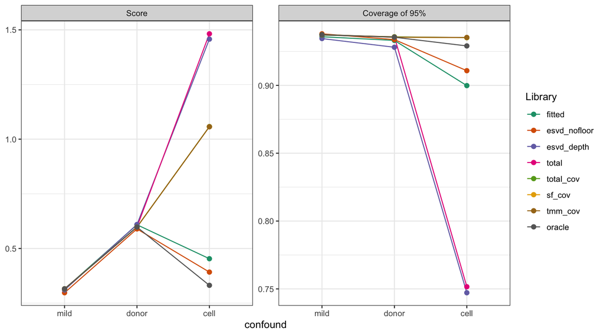

Figure 3. `donor_wls` with each library on the new bank, by level of `confound`: score (left) and coverage of the 95% interval (right), marginal truth.

**Without cell-level confounders the fitted library is barely better than the summed counts.** The gain over `total` is 0.004 nats on the first bank and 0.016 on the second; on the new bank it is 0.001 at `confound = mild` and -0.010 at `donor`. The first loop’s margin over DESeq2 (0.054) is therefore the regression and its variance moderation, not the library: `donor_wls@total` keeps 0.050 of it on the first bank and 0.046 of 0.062 on the second. This answers the open question the first run left.

**With cell-level confounders the fitted library is worth 0.604 nats** over the standard practice (`total_cov`) and 1.029 over the summed counts alone. `esvd_depth`, the fitted library without its covariates, is as bad as the summed counts: the whole gain is the covariates in the library, none of it the per-gene depth coefficient.

## 7.2 The other library-reading rules

Table 7. The other rules that read a library: the variant minus the fitted library, mean difference in score (paired SE). Positive: the fitted library is better. `state_adjusted` under the direct truth.

| Rule | Truth | total_cov, bank 1 | total_cov, bank 2 | total_cov, bank 3, cell | total_cov, bank 3, other | esvd_nofloor, bank 3 |
| --- | --- | --- | --- | --- | --- | --- |
| `raw_null` | marginal | +0.051 (0.006) | +0.043 (0.005) | +0.369 (0.019) | +0.243 | -0.013 (0.003) |
| `gap_trend` | marginal | +0.009 (0.001) | +0.017 (0.002) | +0.630 (0.029) | +0.013 | -0.031 (0.002) |
| `embed_prior` | marginal | +0.004 (0.000) | +0.024 (0.002) | +0.604 (0.029) | +0.001 | -0.036 (0.003) |
| `state_adjusted` | direct | +0.003 (0.000) | -0.000 (0.001) | +0.472 (0.022) | -0.017 | -0.034 (0.003) |

The pattern is `donor_wls`’s for every rule: a large gain from the fitted library at `confound = cell`, a small one or none elsewhere. `raw_null` depends on the fitted library most, because it has no design of its own and the library is its only adjustment for any covariate.

## 7.3 The posterior’s floor on the library

Table 8. Score of `donor_wls` on the new bank with the fitted library as the posterior floors it, without the floor, and with the oracle library, by the gene’s share of zeros (marginal truth); the last four columns at `confound = mild` and `cell`.

| Share of zeros | Cells at the floor | `donor_wls` | `donor_wls@esvd_nofloor` | `donor_wls@oracle` | `donor_wls`, mild | `donor_wls@esvd_nofloor`, mild | `donor_wls`, cell | `donor_wls@esvd_nofloor`, cell |
| --- | --- | --- | --- | --- | --- | --- | --- | --- |
| under 50% | 0% | 0.153 | 0.135 | 0.151 | 0.036 | 0.017 | 0.096 | 0.076 |
| 50 to 80% | 3% | 0.326 | 0.309 | 0.313 | 0.190 | 0.174 | 0.271 | 0.258 |
| 80 to 95% | 49% | 0.657 | 0.588 | 0.570 | 0.474 | 0.443 | 0.699 | 0.562 |
| over 95% | 97% | 0.929 | 0.908 | 0.831 | 0.752 | 0.758 | 1.022 | 0.936 |

`compute_posterior()` sets every fitted library below `library_min = 0.1` to 0.1, and every rule of the loops read the library after that step. For a gene with 80 to 95% zeros about half of the cells are at the floor; above 95% nearly all are (Table 8). Removing the floor improves `donor_wls` by 0.032 nats on the new bank (paired SE 0.003, better in 81% of cohorts) and by 0.007 on the second bank (SE 0.001); on the first bank, which has no sparse gene, it changes nothing. The gain is largest at `confound = cell`, where the floored genes lose their covariate adjustment, and it also improves `state_adjusted` under the direct truth by 0.034 (SE 0.003). Without the floor `donor_wls` is within 0.011 nats of the oracle library on the new bank.

This is a change to which library the rule reads, not a new rule: the formula of `donor_wls` is untouched.

The summed counts, or any standard size factor, are as effective as eSVD’s library unless a confounder varies within donors; when one does, the fitted library is worth half a nat per gene over the standard practice, and all of that comes from the covariates in it. The rule should read the fitted library before the posterior’s floor at 0.1, which otherwise discards the adjustment for sparse genes.

# 8 Sparsity and the number of true DEGs

`lfcse-bank-3`. Genes are binned by their share of zero counts in the cohort; cohorts by the factor `deg`.

Table 9. Score on the new bank by the gene’s share of zero counts, marginal truth.

| Method | under 50% | 50 to 80% | 80 to 95% | over 95% |
| --- | --- | --- | --- | --- |
| `stored` | 0.461 | 0.566 | 0.971 | 1.566 |
| `null_rescaled` | 0.778 | 0.415 | 0.697 | 1.249 |
| `raw_null` | 0.245 | 0.396 | 0.712 | 1.141 |
| `donor_wls` | 0.153 | 0.326 | 0.657 | 0.929 |
| `donor_wls@esvd_nofloor` | 0.135 | 0.309 | 0.588 | 0.908 |
| `donor_wls@total_cov` | 0.395 | 0.557 | 0.809 | 1.071 |
| `state_adjusted` | 0.335 | 0.383 | 0.642 | 0.954 |
| `deseq2` | 0.441 | 0.578 | 0.832 | 1.239 |

Table 10. Slope of the reported logFC on the direct truth, over the genes of each sparsity bin with a nonzero effect. 1 is no attenuation.

| Method | under 50% | 50 to 80% | 80 to 95% | over 95% |
| --- | --- | --- | --- | --- |
| `stored` | 0.922 | 0.946 | 0.955 | 0.994 |
| `null_rescaled` | 0.944 | 0.978 | 1.003 | 0.994 |
| `raw_null` | 0.954 | 0.981 | 1.034 | 1.002 |
| `donor_wls` | 0.964 | 0.986 | 0.998 | 0.872 |
| `donor_wls@esvd_nofloor` | 0.974 | 0.989 | 0.974 | 0.864 |
| `donor_wls@total_cov` | 0.983 | 0.986 | 0.972 | 0.843 |
| `state_adjusted` | 0.951 | 0.974 | 0.982 | 0.825 |
| `deseq2` | 0.968 | 0.981 | 0.989 | 1.016 |

Table 11. Coverage of the 95% interval by the gene’s share of zero counts, marginal truth.

| Method | under 50% | 50 to 80% | 80 to 95% | over 95% |
| --- | --- | --- | --- | --- |
| `stored` | 0.885 | 0.965 | 0.995 | 1.000 |
| `null_rescaled` | 0.775 | 0.924 | 0.985 | 0.998 |
| `raw_null` | 0.954 | 0.958 | 0.961 | 0.970 |
| `donor_wls` | 0.934 | 0.924 | 0.912 | 0.918 |
| `donor_wls@esvd_nofloor` | 0.940 | 0.931 | 0.921 | 0.908 |
| `donor_wls@total_cov` | 0.933 | 0.935 | 0.940 | 0.938 |
| `state_adjusted` | 0.886 | 0.898 | 0.912 | 0.933 |
| `deseq2` | 0.922 | 0.936 | 0.951 | 0.964 |

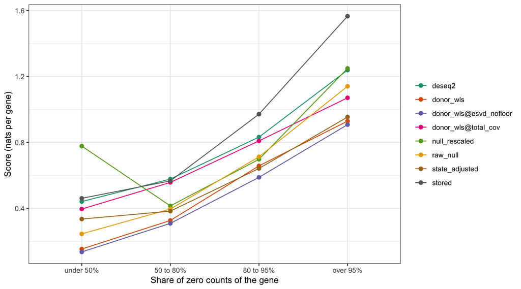

**The posterior-based rules break at both ends.** `stored`’s interval covers 100% of the sparsest genes and 89% of the densest: its SE is dominated by the within-cell term, which is far too large for a sparse gene. `null_rescaled` multiplies every gene’s SE by one factor and so covers 77% of the dense genes.

**`donor_wls` attenuates the sparsest genes.** For genes over 95% zeros its slope on the truth is 0.87 (DESeq2: 1.02). The half count added to a donor’s summed count before the logarithm pulls the donor means together when a donor has a handful of counts. The attenuation is absent below 95% zeros (1.00 at 80 to 95%). It explains the marginal `slope_weak` of 0.90 in Table 3, which sits at the edge of the loops’ gate; on genes under 95% zeros the rule is inside it.

Table 12. Score on the new bank by the number of true DEGs: `few` (5%), `many` (30%, three in four up), `dense` (every gene weakly nonzero).

| Method | few, marginal | many, marginal | dense, marginal | few, direct | many, direct | dense, direct |
| --- | --- | --- | --- | --- | --- | --- |
| `stored` | 0.792 | 0.861 | 0.768 | 0.832 | 0.920 | 0.818 |
| `null_rescaled` | 0.783 | 0.776 | 0.691 | 0.870 | 0.854 | 0.775 |
| `raw_null` | 0.537 | 0.579 | 0.550 | 0.571 | 0.613 | 0.589 |
| `donor_wls` | 0.452 | 0.478 | 0.446 | 0.572 | 0.610 | 0.579 |
| `donor_wls@esvd_nofloor` | 0.428 | 0.432 | 0.419 | 0.546 | 0.564 | 0.551 |
| `state_adjusted` | 0.512 | 0.575 | 0.509 | 0.232 | 0.307 | 0.252 |
| `deseq2` | 0.707 | 0.716 | 0.710 | 0.788 | 0.817 | 0.815 |

**The number of true DEGs moves the scores little.** `donor_wls` scores 0.452 with 5% DEGs and 0.478 with 30% mostly upregulated, where every total-count library is shifted by the DEGs and the empirical null’s mean has to remove the shift. The median logFC of exactly null genes stays at -0.045 at `many` (`stored`: -0.159).

The ranking of the rules is the same for dense and sparse genes and for few and many DEGs. Two things are specific to sparse genes: the posterior-based SE is several times too large for them, and `donor_wls` shrinks the fold change of genes with over 95% zeros by about 13%. Genes that sparse are usually filtered before a DE analysis; the SE and the logFC reported for them should be read with that in mind.

# 9 Technical replicates

`lfcse-bank-3`, examples at `deg = few` and `many`: the two replicate cohorts of an example share the population (the genes’ true effects) and nothing else. A true DEG has a case-control effect of its own; a null gene has none.

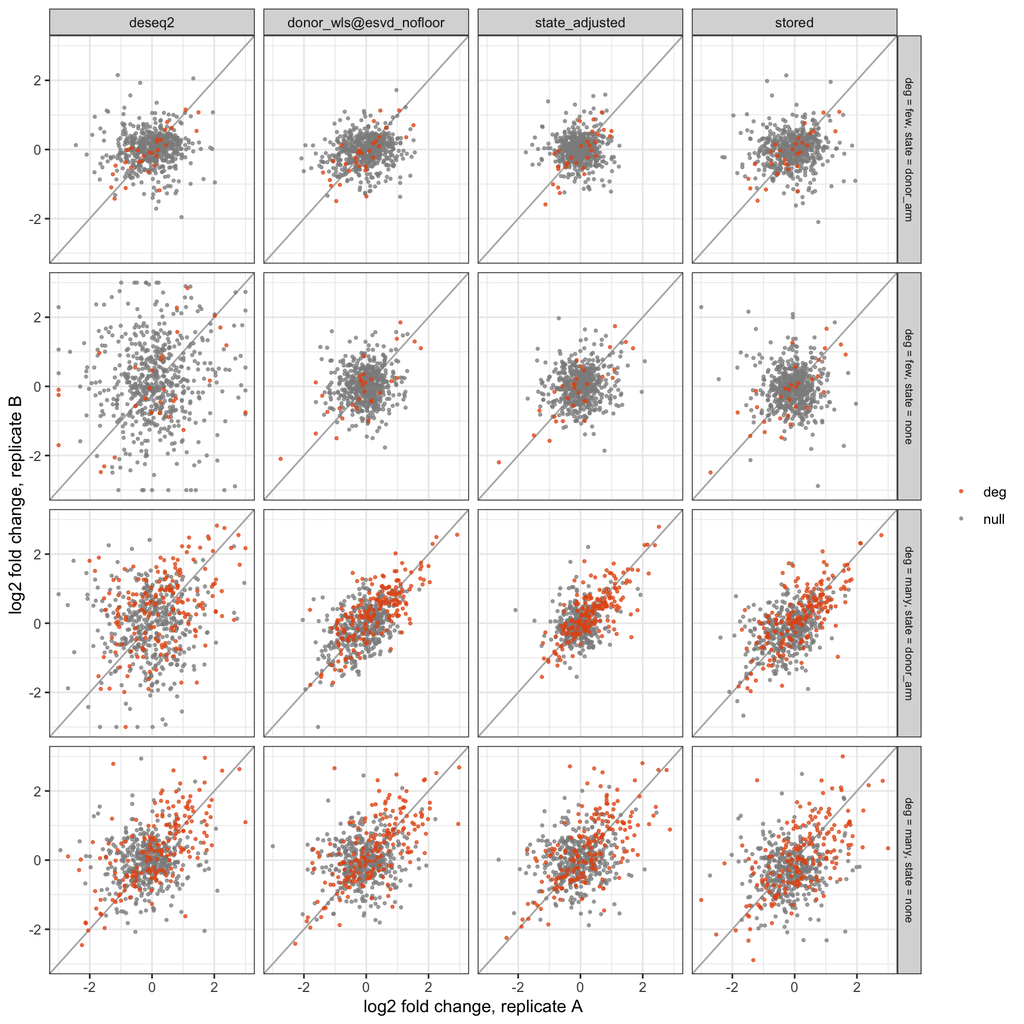

Table 13. Agreement of the logFC between the two replicate cohorts: median over examples of the Pearson correlation over true DEGs and over null genes, the share of DEGs with the same sign, and the mean and SD of the null genes’ logFC. First five columns and the two `cell` columns: examples at `state = none` and `donor`; last column: `state = donor_arm`.

| Method | DEGs: correlation | DEGs: same sign | Null: correlation | Null: mean logFC | Null: SD of logFC | Null: correlation, cell | DEGs: correlation, cell | Null: correlation, donor_arm |
| --- | --- | --- | --- | --- | --- | --- | --- | --- |
| `stored` | 0.778 | 0.808 | -0.005 | -0.098 | 0.467 | -0.007 | 0.797 | 0.297 |
| `null_rescaled` | 0.779 | 0.817 | 0.051 | -0.012 | 0.476 | 0.037 | 0.791 | 0.300 |
| `raw_null` | 0.808 | 0.833 | 0.128 | -0.011 | 0.504 | 0.114 | 0.808 | 0.364 |
| `donor_wls` | 0.800 | 0.819 | 0.050 | -0.013 | 0.435 | 0.099 | 0.823 | 0.326 |
| `donor_wls@esvd_nofloor` | 0.795 | 0.808 | 0.003 | -0.015 | 0.428 | -0.012 | 0.786 | 0.247 |
| `donor_wls@total_cov` | 0.742 | 0.800 | -0.008 | -0.020 | 0.507 | -0.024 | 0.391 | 0.232 |
| `state_adjusted` | 0.816 | 0.833 | 0.048 | -0.010 | 0.386 | 0.141 | 0.843 | 0.059 |
| `deseq2` | 0.718 | 0.800 | -0.025 | -0.028 | 0.546 | -0.029 | 0.428 | 0.214 |

Table 14. Median replicate correlation of the logFC by the gene’s share of zeros (examples at `state = none` and `donor`; a bin needs at least 8 genes of the set in the example).

| Genes | Share of zeros | `deseq2` | `donor_wls@esvd_nofloor` | `state_adjusted` | `stored` |
| --- | --- | --- | --- | --- | --- |
| deg | under 50% | 0.816 | 0.892 | 0.925 | 0.879 |
| deg | 50 to 80% | 0.781 | 0.854 | 0.893 | 0.850 |
| deg | 80 to 95% | 0.689 | 0.763 | 0.787 | 0.781 |
| deg | over 95% | 0.542 | 0.589 | 0.572 | 0.586 |
| null | under 50% | -0.043 | -0.003 | 0.021 | -0.056 |
| null | 50 to 80% | -0.002 | -0.010 | 0.029 | -0.056 |
| null | 80 to 95% | -0.024 | 0.002 | 0.050 | -0.012 |
| null | over 95% | -0.021 | -0.001 | 0.034 | 0.039 |

**True DEGs replicate and null genes do not, as expected, for every rule.** For `donor_wls@esvd_nofloor` the median correlation between replicates is 0.79 over the true DEGs and 0.00 over the null genes, whose logFC is centred at -0.015. The logFC that 1.2.0 stores (`stored`) replicates as well over the DEGs (0.78) but its null genes are centred at -0.10: the depth bias the empirical null’s mean removes in the other rules.

**The DEGs replicate better under the eSVD-library rules than under DESeq2** (0.72), and much better with cell-level confounders (0.79 against 0.43), where DESeq2’s logFC is noisy.

**At `state = donor_arm` the “null” genes replicate under every rule but `state_adjusted`** (0.25 for `donor_wls@esvd_nofloor`, 0.06 for `state_adjusted`). This is not an error: the arms differ in cell state in the population, so those genes have a real marginal effect, and it replicates. It is the fork between the two targets seen from the replicates’ side.

**Sparse DEGs replicate less** (Table 14): the correlation falls from about 0.9 under 50% zeros to about 0.6 over 95%, for every rule.

The picture Kevin expected holds for every rule: true DEGs fall on the diagonal between replicates and null genes form a centred cloud. The replicate correlation of null genes is zero only when the rule has removed the confounders, which makes it a diagnostic one could compute on real replicate cohorts; it is how the floored library’s leftover confounding shows up without the truth.

# 10 Significant genes against the interval

All three banks, pooled over cohorts. Two tests call genes at FDR 5%: **eSVD-DE’s test** (the p-value 1.2.0 computes from the posterior-based Welch statistic and the empirical null, with BH; the same calls for every rule) and **the rule’s own Wald test** ($\widehat\beta_g / s_g$ against a standard normal, with BH; DESeq2’s adjusted p-value for DESeq2). The interval is $\widehat\beta_g \pm 2 s_g$.

Table 15. Of the genes eSVD-DE’s test calls at FDR 5%, the share whose reported interval (logFC plus or minus 2 SE) leaves out zero, by rule; the last column is the share of those genes whose interval covers the true marginal logFC (bank 3).

| Method | Bank 1 | Bank 2 | Bank 3 | Bank 3, few | Bank 3, many | Interval covers the truth |
| --- | --- | --- | --- | --- | --- | --- |
| `stored` | 62% | 64% | 75% | 65% | 81% | 78% |
| `null_rescaled` | 100% | 100% | 100% | 100% | 100% | 57% |
| `raw_null` | 99% | 82% | 65% | 52% | 76% | 88% |
| `donor_wls` | 99% | 86% | 77% | 60% | 86% | 85% |
| `donor_wls@esvd_nofloor` | 99% | 86% | 76% | 59% | 85% | 86% |
| `donor_wls@total_cov` | 99% | 86% | 66% | 52% | 75% | 87% |
| `gap_trend` | 98% | 83% | 78% | 61% | 86% | 85% |
| `embed_prior` | 99% | 83% | 75% | 58% | 85% | 86% |
| `state_adjusted` | 99% | 78% | 64% | 41% | 78% | 80% |
| `deseq2` | 99% | 88% | 67% | 52% | 76% | 85% |

Table 16. The calls of each test at a nominal FDR of 5%: genes called per cohort, false discovery proportion (a false discovery has a marginal truth of exactly zero) and power (over every gene with a nonzero marginal truth, the weak effects of `dense` and `donor_arm` included, hence the low values) on the new bank, pooled over cohorts; the false discovery proportion on the earlier banks.

| Test | Genes called per cohort | False discovery proportion | FDP, few | FDP, many | Power | FDP, bank 2 | FDP, bank 1 |
| --- | --- | --- | --- | --- | --- | --- | --- |
| eSVD-DE’s test (1.2.0) | 34.1 | 19.1% | 49.1% | 14.0% | 7.2% | 18.4% | 7.9% |
| Wald test of `stored` | 18.8 | 15.9% | 42.0% | 13.1% | 4.2% | 2.8% | 1.0% |
| Wald test of `null_rescaled` | 47.2 | 21.5% | 51.6% | 17.6% | 9.7% | 21.2% | 10.6% |
| Wald test of `raw_null` | 16.6 | 6.8% | 22.4% | 4.1% | 4.1% | 12.6% | 13.3% |
| Wald test of `donor_wls` | 40.7 | 5.6% | 9.1% | 6.9% | 10.1% | 4.1% | 3.2% |
| Wald test of `donor_wls@esvd_nofloor` | 38.8 | 4.8% | 9.5% | 5.5% | 9.7% | 3.9% | 3.2% |
| Wald test of `donor_wls@total_cov` | 28.9 | 4.9% | 17.5% | 3.5% | 7.2% | 4.7% | 3.4% |
| Wald test of `gap_trend` | 32.4 | 4.5% | 4.2% | 6.1% | 8.1% | 1.6% | 1.7% |
| Wald test of `embed_prior` | 39.4 | 5.7% | 8.9% | 7.0% | 9.8% | 4.2% | 3.4% |
| Wald test of `state_adjusted` | 32.4 | 4.5% | 7.2% | 5.5% | 8.1% | 4.2% | 2.8% |
| Wald test of `deseq2` | 28.0 | 5.4% | 15.8% | 4.9% | 7.0% | 5.6% | 7.8% |

**What the question asks.** Of the genes eSVD-DE’s test calls, the interval of the logFC that 1.2.0 stores leaves out zero for 75% on the new bank (64% on the second, 62% on the first). On the Velmeshev cohort the same number was 13%. For `donor_wls@esvd_nofloor` it is 76% on the new bank and 99% on the first. `null_rescaled` gives 100% by construction: its z-statistic is the test’s.

**A rule’s own Wald test agrees with its interval by construction**: a gene called by BH at 5% has $|z| > 1.96$ at least, and on the new bank at least 100.0% of the genes a rule calls have $|z| > 2$, for every rule. The disagreement in Table 15 is entirely between two analyses: the package’s test, built on the posterior, and the reported pair, built on donor-level summaries.

**Where the two disagree, the package’s test is the less calibrated of the two.** Its false discovery proportion at a nominal 5% is 19% over the new bank and 49% at `deg = few` (18% on the second bank, 8% on the first). The Wald test of `donor_wls@esvd_nofloor` has 4.8% (9.5% at `few`) with more power (9.7% against 7.2%), and DESeq2 5.4% (15.8% at `few`).

On the first bank the genes eSVD-DE calls and the `donor_wls` interval agree (99%). On the second and the new bank 14% and 24% of the called genes have an interval that covers zero, and there the package’s test has three to four times its nominal false discovery proportion while the Wald test of the reported pair is near nominal. If the reported pair comes from `donor_wls`, the p-value should come from the same pair, or the two will keep contradicting each other in the output table.